# MLS4001: Estatística Aplicada à Medicina

Aula 01: Ler e descrever arquivo de dados em R

José O Siqueira (siqueira@usp.br) Paulo SP Silveira (silveira@usp.br)

13 agosto 2023 15:04h

# Carregar pacotes

```r
options(warn=-1)
suppressMessages(library(knitr, warn.conflicts=FALSE))
# devtools::install_github("kupietz/kableExtra")
suppressMessages(library(kableExtra, warn.conflicts=FALSE))
suppressMessages(library(readxl, warn.conflicts=FALSE))
suppressMessages(library(finalfit, warn.conflicts=FALSE))
suppressMessages(library(car, warn.conflicts=FALSE))
suppressMessages(library(GGally, warn.conflicts=FALSE))
suppressMessages(library(ggplot2, warn.conflicts=FALSE))
suppressMessages(library(psych, warn.conflicts=FALSE))
suppressMessages(library(DescTools, warn.conflicts=FALSE))
suppressMessages(library(MVN, warn.conflicts=FALSE))
suppressMessages(library(ggpubr, warn.conflicts=FALSE))
suppressMessages(library(sjPlot, warn.conflicts=FALSE))
suppressMessages(library(Hmisc, warn.conflicts=FALSE))
suppressMessages(library(summarytools, warn.conflicts=FALSE))
suppressMessages(library(read.dbc, warn.conflicts=FALSE))
suppressMessages(library(reshape2, warn.conflicts=FALSE))
suppressMessages(library(data.table, warn.conflicts=FALSE))
suppressMessages(library(gplots, warn.conflicts=FALSE))
suppressMessages(library(lubridate, warn.conflicts=FALSE))
suppressMessages(library(dplyr, warn.conflicts=FALSE))
suppressMessages(library(FSA, warn.conflicts=FALSE))
suppressMessages(library(lattice, warn.conflicts=FALSE))
suppressMessages(library(htmltools, warn.conflicts=FALSE))
```

```r
Sys.setlocale("LC_CTYPE", "pt_BR.UTF-8")
```

```
[1] "pt_BR.UTF-8"
```

```r
Sys.setlocale("LC_ALL", "pt_BR.UTF-8")
```

```
[1] "LC_COLLATE=pt_BR.UTF-8;LC_CTYPE=pt_BR.UTF-8;LC_MONETARY=pt_BR.UTF-8;LC_NUMERIC=C;LC_TIME=pt_BR.UTF-8"
```

# Pensamento

## Vídeo: Clima “atípico” em Angola deixa menina do tempo preocupada: temperaturas mínimas mais altas que as máximas!

[video not shown]

https://www.youtube.com/watch?v=Jp0jJMPWl6g&t=2s

# Material

- https://drive.google.com/drive/folders/1Cadw9nO_r5rSYFhyhJknpVZYBh4gvccA?usp=sharing
- Baixar os arquivos no seu computador
- Abrir os arquivos `html` no navegador

# R

A linguagem R é uma linguagem de programação e ambiente de desenvolvimento voltado principalmente para análise estatística, manipulação de dados, visualização e criação de gráficos. Ela foi desenvolvida inicialmente por Ross Ihaka e Robert Gentleman na Universidade de Auckland, Nova Zelândia, em 2000.

O R é uma linguagem interpretada e de código aberto, o que significa que seu código-fonte está disponível livremente para que os usuários possam visualizar, modificar e distribuir. Essa característica da linguagem R encoraja uma comunidade colaborativa, levando a um grande ecossistema de pacotes e extensões criados por diversos desenvolvedores em todo o mundo.

Principais características da linguagem R:

1. **Análise Estatística:** R é amplamente utilizado em análise estatística e fornece uma grande variedade de funções e bibliotecas estatísticas para realizar cálculos, testes de hipóteses, regressão, análise de séries temporais e muitos outros procedimentos estatísticos.
2. **Manipulação de Dados:** O R oferece recursos avançados para importar, exportar e manipular dados, incluindo a capacidade de trabalhar com estruturas de dados como vetores, matrizes, data frames e listas.
3. **Visualização de Dados:** A linguagem R possui bibliotecas gráficas poderosas para criação de gráficos e visualizações estáticas e interativas, permitindo representar os dados de forma eficiente e atraente.
4. **Programação Funcional:** R é uma linguagem funcional, o que significa que ela suporta funções de primeira classe e operações de alto nível em funções.
5. **Extensibilidade:** Como mencionado anteriormente, R é altamente extensível por meio de pacotes. Há milhares de pacotes disponíveis para diferentes finalidades, permitindo que os usuários ampliem as funcionalidades da linguagem de acordo com suas necessidades.
6. **Comunidade Ativa:** A comunidade de usuários e desenvolvedores do R é ativa e vibrante. Fóruns online, grupos de discussão e conferências são realizadas regularmente para compartilhar conhecimentos, problemas e soluções.

A sintaxe do R é baseada em comandos em estilo inglês e é relativamente fácil de aprender, mesmo para pessoas que não têm uma formação em programação. Sua versatilidade e a ampla gama de pacotes disponíveis tornam o R uma das linguagens mais populares para análise de dados e estatística em diferentes campos, como ciência de dados, pesquisas acadêmicas, finanças, bioinformática, entre outros.

Até setembro de 2021, o Comprehensive R Archive Network (CRAN), o repositório oficial de pacotes R, continha mais de 17.000 pacotes disponíveis para download e uso. No entanto, é importante observar que a quantidade de pacotes R pode mudar ao longo do tempo, pois novos pacotes são desenvolvidos e adicionados regularmente, enquanto outros podem ser descontinuados ou removidos do repositório.

Além do CRAN, também existem outros repositórios de pacotes R, como o Bioconductor (especializado em bioinformática) e o GitHub, onde muitos desenvolvedores disponibilizam seus pacotes. Portanto, a quantidade total de pacotes R disponíveis pode ser ainda maior do que o número presente no CRAN.

- Tutorial de R por Paulo Silveira e José Siqueira
  - https://drive.google.com/drive/folders/11Uxzsrf_yAf69PlIIYFlckCve5-S_glL?usp=sharing
- Curso-R: Ciência de dados em R por Damiani et al.
  - https://livro.curso-r.com/index.html
- Introdução à Análise de Dados em R por Bruno Lucian & Claudia Jakelline
  - https://bookdown.org/bruno_lucian_costa/CursoBasicoR/

# Sumário

- Leitura e gravação de arquivo de dados
- Tipo de variável
- Estatística descritiva gráfica e numérica
- Estrutura do arquivo de dados com medidas repetidas: *wide* e *long*

# Quatro problemas

1. Ler e descrever `Biometria_FMUSP.xlsx`
2. Ler e transformar a estrutura de dados de `NewDrug.xlsx` de formato *wide* para *long* e vice-versa
3. Ler dados em colunas e tabelas dentro de script R
4. Ler e descrever arquivo de dados grande `DOBR2020.dbc` (documentação em `Estrutura_SIM_para_CD.pdf`)

# Ler arquivo de dados em planilha Excel

Os dados da planilha `Biometria_FMUSP.xlsx` foram coletados pelos docentes dos estudantes do segundo ano de uma mesma disciplina do curso de Medicina da FMUSP em três anos consecutivos.

As variáveis do arquivo são:

- ID: idenficador do(a) estudante
- Ano da coleta dos dados: 1, 2, 3
- Turma: A, B
- Sexo: Feminino, Masculino
- Mao: Destro, Canhoto, Ambidestro
- TipoSang: A+, A-, …
- ABO: A, B, AB, O
- Rh: +, -
- AtivFisica: nível de atividade física
- Sedentarismo: Não, Sim
- MCT: massa corporal total (kg)
- Estatura: cm

```r
Dados <- readxl::read_excel(path="Biometria_FMUSP.xlsx",
                            sheet="dados",
                            na=c("NA","na","nA","Na"))
```

## Dados

```r
knitr::kable(head(Dados), format="html", caption="Biometria FMUSP")
```

Biometria FMUSP

ID

Ano

Turma

Sexo

Mao

TipoSang

ABO

AtivFisica

Sedentarismo

MCT

Estatura

Rh

1

2

B

M

D

A+

A

baixa_intensidade

N

68

173

2

2

B

M

D

A+

A

atualmente_inativo

S

82

175

3

1

B

M

D

A+

A

media_intensidade

N

79

172

4

1

B

F

D

A+

A

media_intensidade

N

49

160

5

1

B

F

D

O-

O

atualmente_inativo

S

52

164

6

3

A

M

D

A+

A

alta_intensidade

N

73

175

```r
knitr::kable(tail(Dados), format="html", caption="Biometria FMUSP")
```

Biometria FMUSP

ID

Ano

Turma

Sexo

Mao

TipoSang

ABO

AtivFisica

Sedentarismo

MCT

Estatura

Rh

544

3

B

F

C

NA

NA

alta_intensidade

N

54

157

NA

545

3

B

F

D

B+

B

alta_intensidade

N

47

157

546

3

B

F

D

B+

B

sempre_inativo

S

48

162

547

3

B

M

A

A+

A

alta_intensidade

N

70

175

548

3

B

M

D

O-

O

atualmente_inativo

S

67

171

549

3

B

F

D

A+

A

media_intensidade

N

45

160

## Estrutura de dados

```r
str(Dados)
```

```
tibble [549 × 12] (S3: tbl_df/tbl/data.frame)
 $ ID          : num [1:549] 1 2 3 4 5 6 7 8 9 10 ...
 $ Ano         : num [1:549] 2 2 1 1 1 3 3 2 3 3 ...
 $ Turma       : chr [1:549] "B" "B" "B" "B" ...
 $ Sexo        : chr [1:549] "M" "M" "M" "F" ...
 $ Mao         : chr [1:549] "D" "D" "D" "D" ...
 $ TipoSang    : chr [1:549] "A+" "A+" "A+" "A+" ...
 $ ABO         : chr [1:549] "A" "A" "A" "A" ...
 $ AtivFisica  : chr [1:549] "baixa_intensidade" "atualmente_inativo" "media_intensidade" "media_intensidade" ...
 $ Sedentarismo: chr [1:549] "N" "S" "N" "N" ...
 $ MCT         : num [1:549] 68 82 79 49 52 73 73 60 75 75 ...
 $ Estatura    : num [1:549] 173 175 172 160 164 175 175 173 182 182 ...
 $ Rh          : chr [1:549] "+" "+" "+" "+" ...
```

# Pré-processamento

Em análise estatística de dados, o pré-processamento refere-se às etapas iniciais e fundamentais que os dados brutos passam antes de serem utilizados para análise estatística propriamente dita. Essas etapas são cruciais para garantir que os dados estejam limpos, organizados e em um formato adequado para que as análises subsequentes sejam precisas e confiáveis.

As principais etapas de pré-processamento incluem:

1. **Coleta:** Esta é a primeira etapa, onde os dados brutos são obtidos a partir de fontes diversas, como pesquisas, sensores, bancos de dados, etc.
2. **Limpeza:** Nesta etapa, os dados são revisados em busca de erros, valores ausentes ou inconsistentes. Dados ausentes podem ser tratados preenchendo-os com valores adequados ou removendo as observações afetadas, dependendo do caso. Outliers (valores extremos que não seguem o padrão dos demais dados) podem ser tratados ou removidos, caso tenham um efeito indesejado na análise.
3. **Transformação e recodificação:** Aqui, os dados podem ser transformados para atender aos requisitos de certos métodos estatísticos. Por exemplo, aplicar logaritmos a dados assimétricos ou normalizar dados para escala comparável.
4. **Integração:** Quando os dados vêm de várias fontes, é necessário combiná-los em um único conjunto de dados coerente e consistente.
5. **Redução de dimensionalidade:** Se os dados tiverem muitas variáveis, é possível utilizar técnicas de redução de dimensionalidade para simplificar a análise e visualização.
6. **Discretização:** Às vezes, é necessário transformar variáveis contínuas em categorias discretas para melhorar a interpretação ou usar certos métodos estatísticos específicos.
7. **Normalização e padronização:** Essas técnicas são aplicadas para garantir que as variáveis estejam em escalas comparáveis, especialmente quando diferentes variáveis têm unidades diferentes.
8. **Seleção de características:** Selecione as variáveis mais relevantes ou informativas para a análise, eliminando as menos relevantes.

Após o pré-processamento, os dados estarão prontos para serem utilizados em análises estatísticas, como regressão, análise de variância, análise de componentes principais, clustering, entre outras. O processo de pré-processamento pode variar dependendo da natureza dos dados e das questões de pesquisa específicas em análise estatística.

```r
print(summary(Dados))
```

```
       ID           Ano           Turma               Sexo
 Min.   :  1   Min.   :1.000   Length:549         Length:549
 1st Qu.:138   1st Qu.:1.000   Class :character   Class :character
 Median :275   Median :2.000   Mode  :character   Mode  :character
 Mean   :275   Mean   :2.095
 3rd Qu.:412   3rd Qu.:3.000
 Max.   :549   Max.   :3.000

     Mao              TipoSang             ABO             AtivFisica
 Length:549         Length:549         Length:549         Length:549
 Class :character   Class :character   Class :character   Class :character
 Mode  :character   Mode  :character   Mode  :character   Mode  :character




 Sedentarismo            MCT            Estatura          Rh
 Length:549         Min.   : 41.00   Min.   :120.0   Length:549
 Class :character   1st Qu.: 56.00   1st Qu.:164.0   Class :character
 Mode  :character   Median : 64.00   Median :172.0   Mode  :character
                    Mean   : 66.76   Mean   :170.8
                    3rd Qu.: 73.00   3rd Qu.:177.0
                    Max.   :658.00   Max.   :195.0
                    NA's   :6        NA's   :6
```

```r
print(sapply(Dados, class))
```

```
          ID          Ano        Turma         Sexo          Mao     TipoSang
   "numeric"    "numeric"  "character"  "character"  "character"  "character"
         ABO   AtivFisica Sedentarismo          MCT     Estatura           Rh
 "character"  "character"  "character"    "numeric"    "numeric"  "character"
```

```r
Dados <- dplyr::mutate_if(Dados, is.character, as.factor)
Dados <- dplyr::mutate_at(Dados, dplyr::vars(ID), as.factor)
print(summary(Dados))
```

```
       ID           Ano        Turma   Sexo      Mao         TipoSang
 1      :  1   Min.   :1.000   A:285   F:232   A   : 28   A+     :171
 2      :  1   1st Qu.:1.000   B:264   M:317   C   : 37   O+     :132
 3      :  1   Median :2.000                   D   :442   B+     : 65
 4      :  1   Mean   :2.095                   NA's: 42   A-     : 49
 5      :  1   3rd Qu.:3.000                              O-     : 45
 6      :  1   Max.   :3.000                              (Other): 76
 (Other):543                                              NA's   : 11
   ABO                   AtivFisica  Sedentarismo      MCT
 A   :220   alta_intensidade  :168   N:316        Min.   : 41.00
 AB  : 42   atualmente_inativo:152   S:233        1st Qu.: 56.00
 B   : 99   baixa_intensidade : 59                Median : 64.00
 O   :177   media_intensidade : 99                Mean   : 66.76
 NA's: 11   sempre_inativo    : 71                3rd Qu.: 73.00
                                                  Max.   :658.00
                                                  NA's   :6
    Estatura        Rh
 Min.   :120.0   -   :130
 1st Qu.:164.0   +   :408
 Median :172.0   NA's: 11
 Mean   :170.8
 3rd Qu.:177.0
 Max.   :195.0
 NA's   :6
```

```r
print(sapply(Dados, class))
```

```
          ID          Ano        Turma         Sexo          Mao     TipoSang
    "factor"    "numeric"     "factor"     "factor"     "factor"     "factor"
         ABO   AtivFisica Sedentarismo          MCT     Estatura           Rh
    "factor"     "factor"     "factor"    "numeric"    "numeric"     "factor"
```

```r
print(labelled::look_for(Dados[,-1]))
```

```
 pos variable     label col_type missing values
 1   Ano          —     dbl      0
 2   Turma        —     fct      0       A
                                         B
 3   Sexo         —     fct      0       F
                                         M
 4   Mao          —     fct      42      A
                                         C
                                         D
 5   TipoSang     —     fct      11      A-
                                         A+
                                         AB-
                                         AB+
                                         B-
                                         B+
                                         O-
                                         O+
 6   ABO          —     fct      11      A
                                         AB
                                         B
                                         O
 7   AtivFisica   —     fct      0       alta_intensidade
                                         atualmente_inativo
                                         baixa_intensidade
                                         media_intensidade
                                         sempre_inativo
 8   Sedentarismo —     fct      0       N
                                         S
 9   MCT          —     dbl      6
 10  Estatura     —     dbl      6
 11  Rh           —     fct      11      -
                                         +
```

```r
knitr::kable(head(Dados), format="html", caption="Biometria FMUSP")
```

Biometria FMUSP

ID

Ano

Turma

Sexo

Mao

TipoSang

ABO

AtivFisica

Sedentarismo

MCT

Estatura

Rh

1

2

B

M

D

A+

A

baixa_intensidade

N

68

173

2

2

B

M

D

A+

A

atualmente_inativo

S

82

175

3

1

B

M

D

A+

A

media_intensidade

N

79

172

4

1

B

F

D

A+

A

media_intensidade

N

49

160

5

1

B

F

D

O-

O

atualmente_inativo

S

52

164

6

3

A

M

D

A+

A

alta_intensidade

N

73

175

```r
knitr::kable(tail(Dados), format="html", caption="Biometria FMUSP")
```

Biometria FMUSP

ID

Ano

Turma

Sexo

Mao

TipoSang

ABO

AtivFisica

Sedentarismo

MCT

Estatura

Rh

544

3

B

F

C

NA

NA

alta_intensidade

N

54

157

NA

545

3

B

F

D

B+

B

alta_intensidade

N

47

157

546

3

B

F

D

B+

B

sempre_inativo

S

48

162

547

3

B

M

A

A+

A

alta_intensidade

N

70

175

548

3

B

M

D

O-

O

atualmente_inativo

S

67

171

549

3

B

F

D

A+

A

media_intensidade

N

45

160

```r
print(class(Dados$AtivFisica))
```

```
[1] "factor"
```

```r
print(levels(Dados$AtivFisica))
```

```
[1] "alta_intensidade"   "atualmente_inativo" "baixa_intensidade"
[4] "media_intensidade"  "sempre_inativo"
```

```r
print(summary(subset(Dados, select=c(AtivFisica))))
```

```
              AtivFisica
 alta_intensidade  :168
 atualmente_inativo:152
 baixa_intensidade : 59
 media_intensidade : 99
 sempre_inativo    : 71
```

```r
Dados$AtivFisica <- factor(Dados$AtivFisica,
                           levels=c("sempre_inativo",
                                    "atualmente_inativo",
                                    "baixa_intensidade",
                                    "media_intensidade",
                                    "alta_intensidade"))
print(class(Dados$AtivFisica))
```

```
[1] "factor"
```

```r
print(levels(Dados$AtivFisica))
```

```
[1] "sempre_inativo"     "atualmente_inativo" "baixa_intensidade"
[4] "media_intensidade"  "alta_intensidade"
```

```r
print(summary(subset(Dados, select=AtivFisica)))
```

```
              AtivFisica
 sempre_inativo    : 71
 atualmente_inativo:152
 baixa_intensidade : 59
 media_intensidade : 99
 alta_intensidade  :168
```

```r
print(sjPlot::view_df(subset(Dados, select=c(-ID))))
print(summary(subset(Dados, select=-ID)))
```

```
      Ano        Turma   Sexo      Mao         TipoSang     ABO
 Min.   :1.000   A:285   F:232   A   : 28   A+     :171   A   :220
 1st Qu.:1.000   B:264   M:317   C   : 37   O+     :132   AB  : 42
 Median :2.000                   D   :442   B+     : 65   B   : 99
 Mean   :2.095                   NA's: 42   A-     : 49   O   :177
 3rd Qu.:3.000                              O-     : 45   NA's: 11
 Max.   :3.000                              (Other): 76
                                            NA's   : 11
              AtivFisica  Sedentarismo      MCT            Estatura
 sempre_inativo    : 71   N:316        Min.   : 41.00   Min.   :120.0
 atualmente_inativo:152   S:233        1st Qu.: 56.00   1st Qu.:164.0
 baixa_intensidade : 59                Median : 64.00   Median :172.0
 media_intensidade : 99                Mean   : 66.76   Mean   :170.8
 alta_intensidade  :168                3rd Qu.: 73.00   3rd Qu.:177.0
                                       Max.   :658.00   Max.   :195.0
                                       NA's   :6        NA's   :6
    Rh
 -   :130
 +   :408
 NA's: 11
```

```r
Dados$MCT[Dados$MCT==658] <- NA
Dados$Estatura[Dados$Estatura==120] <- NA
Dados$IMC <- Dados$MCT/((Dados$Estatura/100)^2)
print(summary(subset(Dados, select=c(MCT, Estatura, IMC))))
```

```
      MCT            Estatura          IMC
 Min.   : 41.00   Min.   :153.0   Min.   :14.53
 1st Qu.: 56.00   1st Qu.:164.0   1st Qu.:20.03
 Median : 64.00   Median :172.0   Median :21.79
 Mean   : 65.67   Mean   :170.9   Mean   :22.32
 3rd Qu.: 73.00   3rd Qu.:177.0   3rd Qu.:24.07
 Max.   :125.00   Max.   :195.0   Max.   :40.35
 NA's   :7        NA's   :7       NA's   :8
```

```r
summarytools::view(summarytools::dfSummary(Dados))
```

```
Switching method to 'browser'
```

```
Output file written: C:\Users\User\AppData\Local\Temp\Rtmp8iswdZ\file29d426c178d8.html
```

```r
saveRDS(Dados, "Biometria_FMUSP.rds")
```

## Estratificação da amostra por sexo

```r
Dados <- readRDS("Biometria_FMUSP.rds")

Dados.F <- subset(Dados, Sexo=="F")
Dados.M <- subset(Dados, Sexo=="M")
```

## Análise de dados faltantes

```r
n.total <- nrow(Dados)
n.completo <- nrow(na.omit(Dados))
n.incompleto <- n.total - n.completo
cat("Numero de casos total = ", n.total, "\n", sep="")
```

```
Numero de casos total = 549
```

```r
cat("Numero de casos completos = ", n.completo,
    " (",round(100*n.completo/n.total,2),"%)\n", sep="")
```

```
Numero de casos completos = 488 (88.89%)
```

```r
cat("Numero de casos incompletos = ", n.incompleto,
    " (",round(100*n.incompleto/n.total,2),"%)\n", sep="")
```

```
Numero de casos incompletos = 61 (11.11%)
```

```r
obs.falt <- sum(is.na(Dados))
obs.valid <- sum(!is.na(Dados))
obs.tot <- obs.falt + obs.valid
cat("Numero de observacoes validas = ", obs.valid,
    " (",round(100*obs.valid/obs.tot,2),"%)\n", sep="")
```

```
Numero de observacoes validas = 7040 (98.64%)
```

```r
cat("Numero de observacoes faltantes = ", obs.falt,
    " (",round(100*obs.falt/obs.tot,2),"%)\n", sep="")
```

```
Numero de observacoes faltantes = 97 (1.36%)
```

## Análise de dados faltantes com `finalfit::missing_pattern`

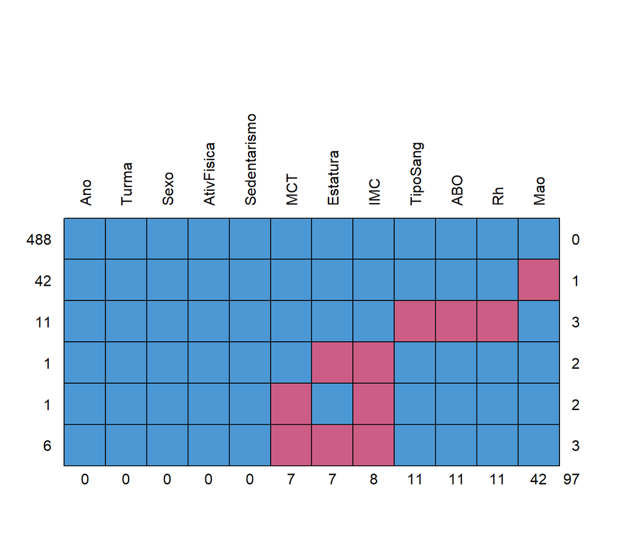

```
    Ano Turma Sexo AtivFisica Sedentarismo MCT Estatura IMC TipoSang ABO Rh Mao
488   1     1    1          1            1   1        1   1        1   1  1   1
42    1     1    1          1            1   1        1   1        1   1  1   0
11    1     1    1          1            1   1        1   1        0   0  0   1
1     1     1    1          1            1   1        0   0        1   1  1   1
1     1     1    1          1            1   0        1   0        1   1  1   1
6     1     1    1          1            1   0        0   0        1   1  1   1
      0     0    0          0            0   7        7   8       11  11 11  42

488  0
42   1
11   3
1    2
1    2
6    3
    97
```

```r
finalfit::missing_pattern(subset(Dados,select=-ID))
```

# Análise exploratória de dados (EDA)

A análise estatística exploratória (ou EDA - *Exploratory Data Analysis*) é uma abordagem de investigação de dados que visa entender a estrutura, padrões e características de um conjunto de dados, antes de realizar análises mais formais ou modelagem estatística. Ela é uma etapa essencial no processo de análise de dados, pois ajuda a obter insights preliminares, identificar tendências, detectar anomalias e formular hipóteses iniciais.

As principais características da análise estatística exploratória são:

1. **Sumarização de dados:** A EDA envolve a utilização de técnicas estatísticas descritivas para resumir os dados em estatísticas como média, mediana, desvio padrão, mínimo, máximo, quartis, histogramas e outras medidas relevantes. Essas estatísticas ajudam a entender a distribuição dos dados e suas principais características.
2. **Visualização de dados:** A EDA faz amplo uso de gráficos e visualizações para representar os dados de maneira compreensível. Gráficos como histogramas, box plots, gráficos de dispersão, gráficos de linha e gráficos de barras são usados para identificar padrões, relacionamentos e tendências nos dados.
3. **Detecção de outliers e dados faltantes:** Durante a análise exploratória, é essencial identificar valores extremos (outliers) e dados ausentes, entender suas possíveis causas e decidir como tratá-los, se necessário.
4. **Análise de correlação:** Explorar correlações entre variáveis ajuda a entender a relação entre diferentes características do conjunto de dados e pode fornecer insights valiosos sobre como elas estão relacionadas.
5. **Análise de distribuição:** Através de gráficos de distribuição, é possível verificar se os dados seguem uma distribuição específica, como normal, uniforme ou exponencial, por exemplo.
6. **Identificação de padrões e tendências:** A EDA permite identificar tendências temporais, sazonalidades, padrões cíclicos e outras estruturas nos dados que podem ser úteis na formulação de perguntas e hipóteses para análises posteriores.

A análise estatística exploratória é frequentemente conduzida usando ferramentas de software estatístico, como o R e Python. Essa etapa é fundamental para estabelecer uma base sólida para a análise posterior e para garantir que a interpretação dos resultados seja feita de forma mais informada e precisa.

## `psych::describe` e `table`

```r
# item name ,item number, nvalid, mean, sd,
# median, mad (Median Absolute Deviation),
# min, max, skew, kurtosis, se
print(psych::describe(subset(Dados, select=c(MCT, Estatura))))
```

```
         vars   n   mean    sd median trimmed   mad min max range skew kurtosis
MCT         1 542  65.67 12.90     64   64.58 13.34  41 125    84 1.04     2.04
Estatura    2 542 170.94  8.92    172  170.80 10.38 153 195    42 0.12    -0.66
           se
MCT      0.55
Estatura 0.38
```

```r
table(Dados$TipoSang)
```

```
 A-  A+ AB- AB+  B-  B+  O-  O+
 49 171   2  40  34  65  45 132
```

```r
round(prop.table(table(Dados$TipoSang)),2)
```

```
  A-   A+  AB-  AB+   B-   B+   O-   O+
0.09 0.32 0.00 0.07 0.06 0.12 0.08 0.25
```

## `tapply`

```r
# mean,median,25th and 75th quartiles,min,max
tapply(Dados$MCT, Dados$Sexo, summary)
```

```
$F
   Min. 1st Qu.  Median    Mean 3rd Qu.    Max.    NA's
  41.00   52.00   56.00   57.63   62.00  120.00       2

$M
   Min. 1st Qu.  Median    Mean 3rd Qu.    Max.    NA's
  43.00   63.00   72.00   71.59   78.00  125.00       5
```

## `psych::describeBy`

```r
# item name, item number, nvalid, mean, sd,
# median, mad (Median Absolute Deviation),
# min, max, skew, kurtosis, se
print(psych::describeBy(subset(Dados,select=c(MCT, Estatura)),
                  group=list(Dados$Sexo),
                  mat=TRUE,
                  digits=2))
```

```
          item group1 vars   n   mean    sd median trimmed   mad min max range
MCT1         1      F    1 230  57.63  9.05     56   56.75  7.41  41 120    79
MCT2         2      M    1 312  71.59 12.09     72   70.88 11.12  43 125    82
Estatura1    3      F    2 229 164.34  6.38    163  163.94  5.93 153 186    33
Estatura2    4      M    2 313 175.77  7.26    175  175.88  7.41 155 195    40
           skew kurtosis   se
MCT1       2.43    12.04 0.60
MCT2       0.90     2.37 0.68
Estatura1  0.61     0.02 0.42
Estatura2 -0.13     0.21 0.41
```

```r
print(psych::describeBy(subset(Dados,select=c(MCT, Estatura)),
                  group=list(Dados$Sexo, Dados$ABO),
                  mat=TRUE,
                  digits=2))
```

```
          item group1 group2 vars   n   mean    sd median trimmed   mad min max
MCT1         1      F      A    1  89  57.79  9.32   57.0   57.12  7.41  43 120
MCT2         2      M      A    1 126  73.21 13.06   72.0   72.16 10.38  50 125
MCT3         3      F     AB    1  14  56.93  5.69   56.5   57.00  6.67  48  65
MCT4         4      M     AB    1  27  71.93 11.33   72.0   71.65  8.90  50 102
MCT5         5      F      B    1  42  55.26  7.02   53.0   54.44  5.19  45  76
MCT6         6      M      B    1  56  68.38 10.48   65.0   67.61  7.41  49  95
MCT7         7      F      O    1  81  59.10 10.07   57.0   57.98  7.41  41 100
MCT8         8      M      O    1  96  71.38 11.48   73.0   71.12 10.38  43 120
Estatura1    9      F      A    2  88 164.59  5.83  164.0  164.39  5.93 153 181
Estatura2   10      M      A    2 126 175.17  6.79  175.0  175.08  7.41 160 192
Estatura3   11      F     AB    2  14 165.21  5.67  164.0  165.08  5.93 156 176
Estatura4   12      M     AB    2  27 175.41  8.95  177.0  175.83  8.90 155 195
Estatura5   13      F      B    2  42 163.43  6.84  162.5  162.76  6.67 153 185
Estatura6   14      M      B    2  57 175.26  7.73  175.0  175.23  5.93 160 195
Estatura7   15      F      O    2  81 164.33  6.90  163.0  163.80  7.41 154 186
Estatura8   16      M      O    2  96 176.98  7.12  177.0  177.14  7.41 156 193
          range  skew kurtosis   se
MCT1         77  3.29    19.99 0.99
MCT2         75  1.12     2.65 1.16
MCT3         17  0.06    -1.50 1.52
MCT4         52  0.47     0.64 2.18
MCT5         31  1.03     0.52 1.08
MCT6         46  0.69     0.08 1.40
MCT7         59  1.69     4.67 1.12
MCT8         77  0.58     2.26 1.17
Estatura1    28  0.39    -0.53 0.62
Estatura2    32  0.09    -0.35 0.61
Estatura3    20  0.25    -1.05 1.52
Estatura4    40 -0.35     0.23 1.72
Estatura5    32  0.91     0.72 1.06
Estatura6    35  0.04    -0.23 1.02
Estatura7    32  0.69    -0.06 0.77
Estatura8    37 -0.36     0.81 0.73
```

```r
print(psych::describeBy(subset(Dados, select=c(MCT, Estatura)),
                  group=list(Dados$ABO, Dados$Sexo),
                  mat=TRUE,
                  digits=2))
```

```
          item group1 group2 vars   n   mean    sd median trimmed   mad min max
MCT1         1      A      F    1  89  57.79  9.32   57.0   57.12  7.41  43 120
MCT2         2     AB      F    1  14  56.93  5.69   56.5   57.00  6.67  48  65
MCT3         3      B      F    1  42  55.26  7.02   53.0   54.44  5.19  45  76
MCT4         4      O      F    1  81  59.10 10.07   57.0   57.98  7.41  41 100
MCT5         5      A      M    1 126  73.21 13.06   72.0   72.16 10.38  50 125
MCT6         6     AB      M    1  27  71.93 11.33   72.0   71.65  8.90  50 102
MCT7         7      B      M    1  56  68.38 10.48   65.0   67.61  7.41  49  95
MCT8         8      O      M    1  96  71.38 11.48   73.0   71.12 10.38  43 120
Estatura1    9      A      F    2  88 164.59  5.83  164.0  164.39  5.93 153 181
Estatura2   10     AB      F    2  14 165.21  5.67  164.0  165.08  5.93 156 176
Estatura3   11      B      F    2  42 163.43  6.84  162.5  162.76  6.67 153 185
Estatura4   12      O      F    2  81 164.33  6.90  163.0  163.80  7.41 154 186
Estatura5   13      A      M    2 126 175.17  6.79  175.0  175.08  7.41 160 192
Estatura6   14     AB      M    2  27 175.41  8.95  177.0  175.83  8.90 155 195
Estatura7   15      B      M    2  57 175.26  7.73  175.0  175.23  5.93 160 195
Estatura8   16      O      M    2  96 176.98  7.12  177.0  177.14  7.41 156 193
          range  skew kurtosis   se
MCT1         77  3.29    19.99 0.99
MCT2         17  0.06    -1.50 1.52
MCT3         31  1.03     0.52 1.08
MCT4         59  1.69     4.67 1.12
MCT5         75  1.12     2.65 1.16
MCT6         52  0.47     0.64 2.18
MCT7         46  0.69     0.08 1.40
MCT8         77  0.58     2.26 1.17
Estatura1    28  0.39    -0.53 0.62
Estatura2    20  0.25    -1.05 1.52
Estatura3    32  0.91     0.72 1.06
Estatura4    32  0.69    -0.06 0.77
Estatura5    32  0.09    -0.35 0.61
Estatura6    40 -0.35     0.23 1.72
Estatura7    35  0.04    -0.23 1.02
Estatura8    37 -0.36     0.81 0.73
```

## `aggregate`

```r
aggregate(subset(Dados, select=c(MCT, Estatura)),
                 by=list(Dados$Sexo),
                 FUN=mean,
                 na.rm=TRUE)
```

```
# A tibble: 2 × 3
  Group.1   MCT Estatura
  <fct>   <dbl>    <dbl>
1 F        57.6     164.
2 M        71.6     176.
```

```r
aggregate(subset(Dados, select=c(MCT, Estatura)),
                 by=list(Dados$Sexo, Dados$ABO),
                 FUN=mean,
                 na.rm=TRUE)
```

```
# A tibble: 8 × 4
  Group.1 Group.2   MCT Estatura
  <fct>   <fct>   <dbl>    <dbl>
1 F       A        57.8     165.
2 M       A        73.2     175.
3 F       AB       56.9     165.
4 M       AB       71.9     175.
5 F       B        55.3     163.
6 M       B        68.4     175.
7 F       O        59.1     164.
8 M       O        71.4     177.
```

```r
aggregate(subset(Dados, select=c(MCT, Estatura)),
                 by=list(Dados$ABO, Dados$Sexo),
                 FUN=mean,
                 na.rm=TRUE)
```

```
# A tibble: 8 × 4
  Group.1 Group.2   MCT Estatura
  <fct>   <fct>   <dbl>    <dbl>
1 A       F        57.8     165.
2 AB      F        56.9     165.
3 B       F        55.3     163.
4 O       F        59.1     164.
5 A       M        73.2     175.
6 AB      M        71.9     175.
7 B       M        68.4     175.
8 O       M        71.4     177.
```

## `aggregate` por fórmula

```r
aggregate(MCT ~ Sexo,
                FUN=median,
                na.rm=TRUE,
                data=Dados)
```

```
# A tibble: 2 × 2
  Sexo    MCT
  <fct> <dbl>
1 F        56
2 M        72
```

```r
aggregate(MCT ~ Sexo + ABO,
                FUN=median,
                na.rm=TRUE,
                data=Dados)
```

```
# A tibble: 8 × 3
  Sexo  ABO     MCT
  <fct> <fct> <dbl>
1 F     A      57
2 M     A      72
3 F     AB     56.5
4 M     AB     72
5 F     B      53
6 M     B      65
7 F     O      57
8 M     O      73
```

## Média e desvio-padrão: Parte A

- Higgins JPT, Li T, Deeks JJ (editors). Chapter 6: Choosing effect measures and computing estimates of effect. In: Higgins JPT, Thomas J, Chandler J, Cumpston M, Li T, Page MJ, Welch VA (editors). Cochrane Handbook for Systematic Reviews of Interventions version 6.3 (updated February 2022). Cochrane, 2022. Available from www.training.cochrane.org/handbook.
  - Table 6.5.a em https://training.cochrane.org/handbook/current/chapter-06
- Suponha que não temos acesso aos dados brutos de MCT. Os dados disponíveis são apresentados na tabela abaixo:

| group | n | mean | sd |
| --- | --- | --- | --- |
| F | 230 | 57.63 | 9.05 |
| M | 312 | 71.59 | 12.09 |

- Quais são os valores da média e desvio-padrão amostrais dos 542 estudantes?

```r
m <- (230*57.63 + 312*71.59)/542
cat("Media = ", round(m,2), "\n", sep="")
```

```
Media = 65.67
```

```r
dp <- sqrt(((230-1)*(9.05^2) + (312-1)*(12.09^2) +
            (230*312/542)*((57.63-71.59)^2))/(542-1))
cat("Desvio-padrao = ", round(dp,2), " > ", max(9.05,12.09), "\n", sep="")
```

```
Desvio-padrao = 12.9 > 12.09
```

## Média e desvio-padrão: Parte B

- MCT

  | n | mean | sd |
  | --- | --- | --- |
  | 542 | 65.67 | 12.9 |

| group | n | mean | sd |
| --- | --- | --- | --- |
| F | 230 | 57.63 | 9.05 |
| M | 312 | 71.59 | 12.09 |

```r
m <- (230*57.63 + 312*71.59)/542
cat("Media = ", round(m,2), "\n", sep="")
```

```
Media = 65.67
```

```r
dp <- sqrt(((230-1)*9.05^2 + (312-1)*12.09^2 +
            (230*312/542)*(57.63-71.59)^2)/(542-1))
cat("Desvio-padrao = ", round(dp,2), "\n", sep="")
```

```
Desvio-padrao = 12.9
```

```r
dp <- sqrt((230*9.05^2 + 312*12.09^2 +
           230*(57.63-65.67)^2 + 312*(71.59-65.67)^2)/542)
cat("Desvio-padrao = ", round(dp,2), "\n", sep="")
```

```
Desvio-padrao = 12.9
```

$$\bar{x} = \dfrac{n_F \, \bar{x}_F + n_M
\, \bar{x}_M}{n_F + n_M}$$

$$s=\sqrt{\dfrac{(n_F-1)\,s_F^2+(n_M-1)\,s_M^2+\dfrac{n_F\;n_M}{n_F+n_M}\left(\bar{x}_F-\bar{x}_M\right)^2}{n_F+n_M-1}}\\
\dfrac{n_F\;n_M}{n_F+n_M}=\text{ média harmônica/2}$$

$$s=\sqrt{\frac{n_F\,s_F^2+n_M\,s_M^2+n_F\,\left(\bar{x}_F-\bar{x}\right)^2+n_M\,\left(\bar{x}_M-\bar{x}\right)^2}{n_F+n_M}}$$

$$s=\sqrt{\frac{n_F\,\left(s_F^2+\left(\bar{x}_F-\bar{x}\right)^2\right)+n_M\,\left(s_M^2+\left(\bar{x}_M-\bar{x}\right)^2\right)}{n_F+n_M}}$$

## Dotplot por `plot` & `table`

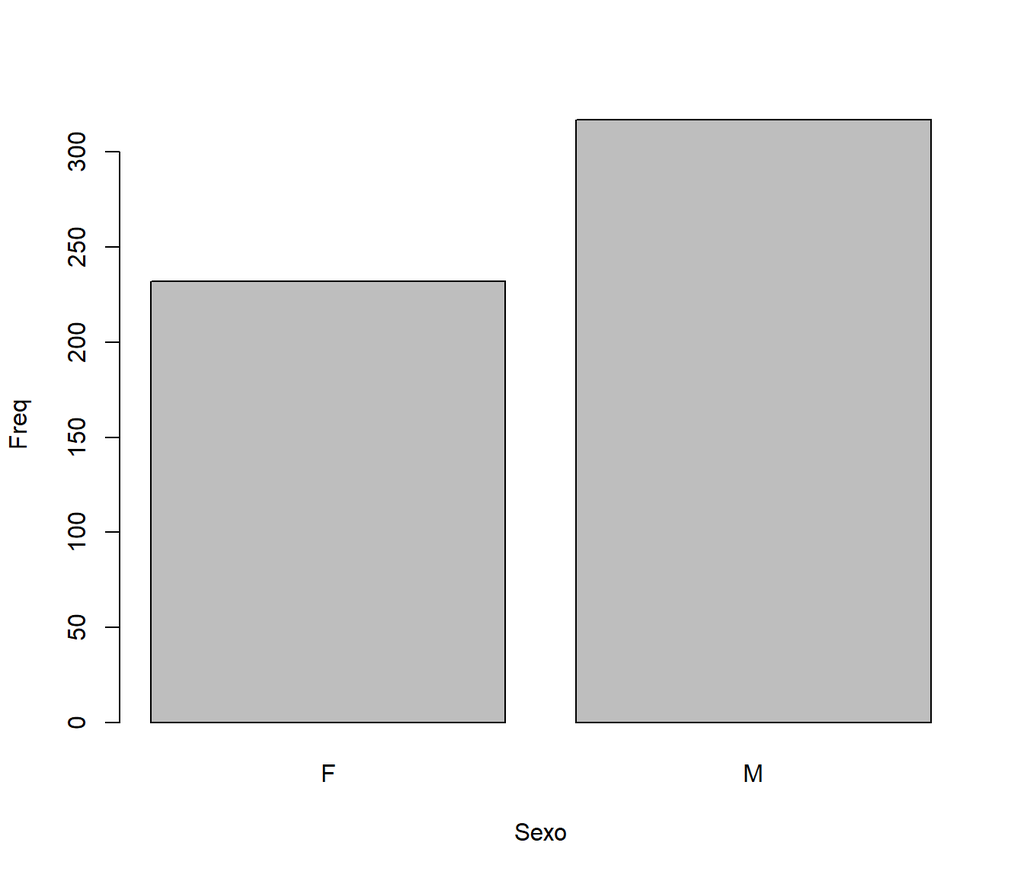

```r
plot(Dados$Sexo, xlab="Sexo", ylab="Freq")
```

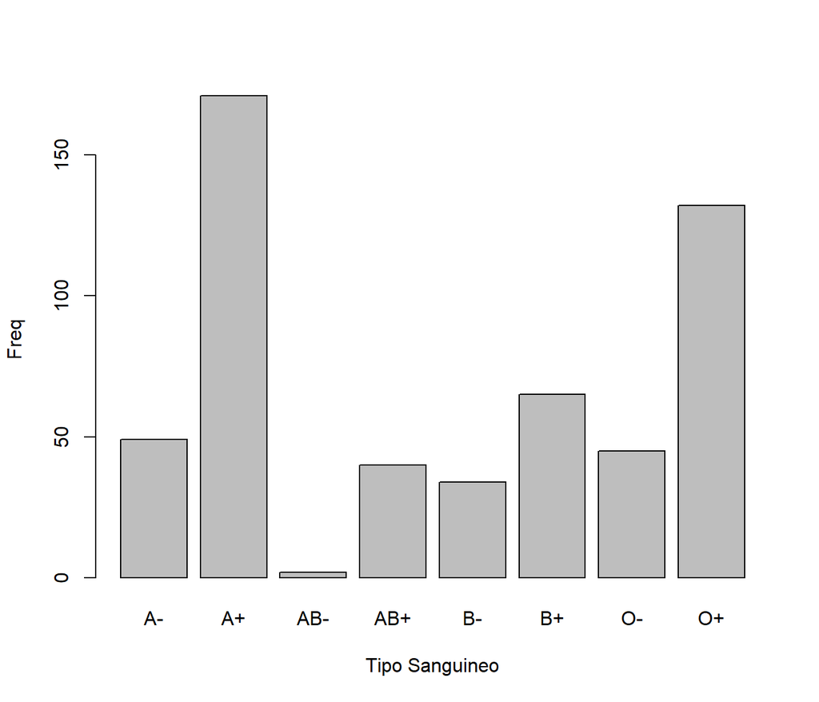

```r
plot(Dados$TipoSang, xlab="Tipo Sanguineo", ylab="Freq")
```

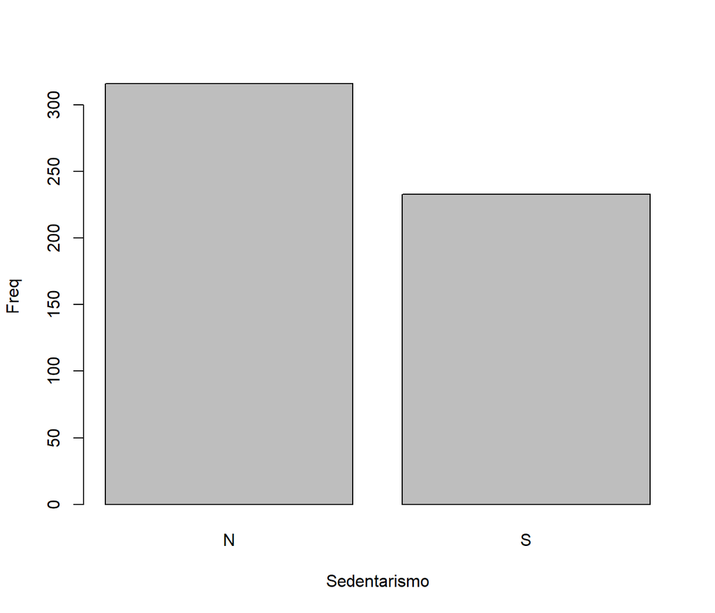

```r
plot(Dados$Sedentarismo, xlab="Sedentarismo", ylab="Freq")
```

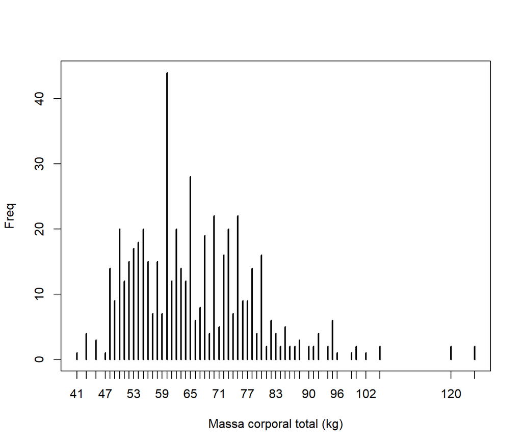

```r
plot(table(Dados$MCT), xlab="Massa corporal total (kg)", ylab="Freq")
```

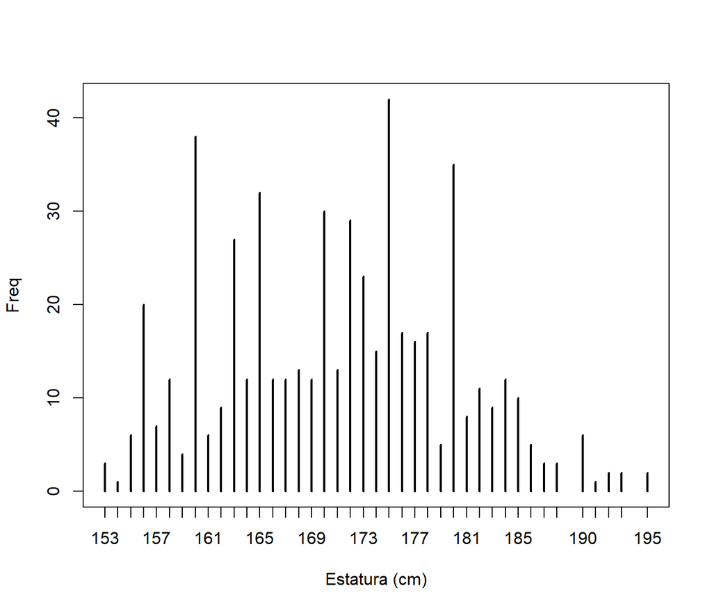

```r
plot(table(Dados$Estatura), xlab="Estatura (cm)", ylab="Freq")
```

## Gráfico de setores

```r
table(Dados$Sexo)
```

```
  F   M
232 317
```

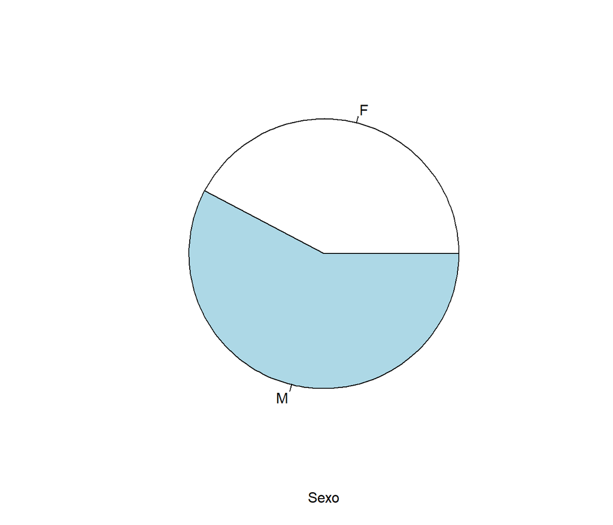

```r
pie(table(Dados$Sexo),
    xlab="Sexo")
```

```r
table(Dados$ABO)
```

```
  A  AB   B   O
220  42  99 177
```

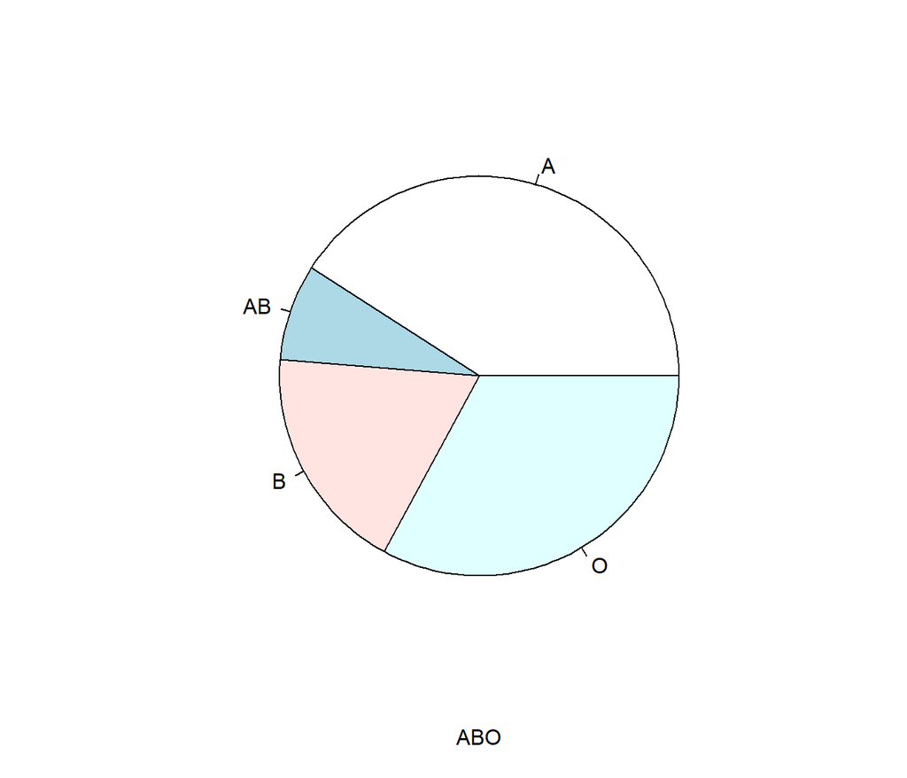

```r
pie(table(Dados$ABO),
    xlab="ABO")
```

## Tabela de contingência 2x2

```r
print(Sedentarismo.Sexo <- xtabs(~Sedentarismo+Sexo, data=Dados))
```

```
            Sexo
Sedentarismo   F   M
           N 133 183
           S  99 134
```

```r
margin.table(Sedentarismo.Sexo,1)
```

```
Sedentarismo
  N   S
316 233
```

```r
margin.table(Sedentarismo.Sexo,2)
```

```
Sexo
  F   M
232 317
```

```r
round(proportions(Sedentarismo.Sexo),2)
```

```
            Sexo
Sedentarismo    F    M
           N 0.24 0.33
           S 0.18 0.24
```

```r
round(proportions(Sedentarismo.Sexo,1),2)
```

```
            Sexo
Sedentarismo    F    M
           N 0.42 0.58
           S 0.42 0.58
```

```r
round(proportions(Sedentarismo.Sexo,2),2)
```

```
            Sexo
Sedentarismo    F    M
           N 0.57 0.58
           S 0.43 0.42
```

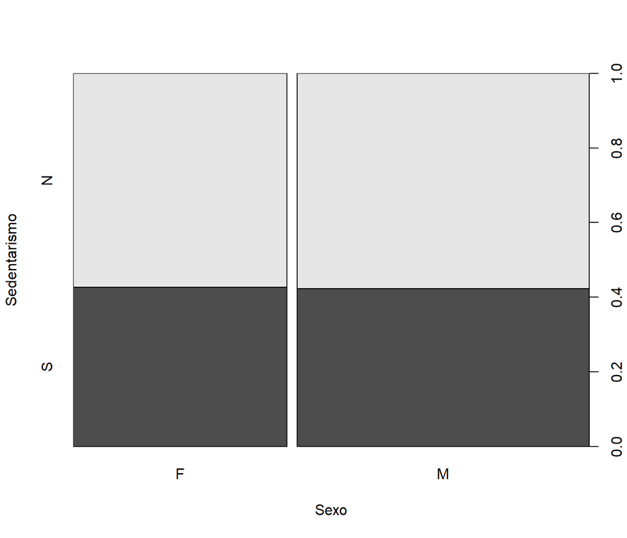

```r
plot(Dados$Sedentarismo~Dados$Sexo, xlab="Sexo", ylab="Sedentarismo")
```

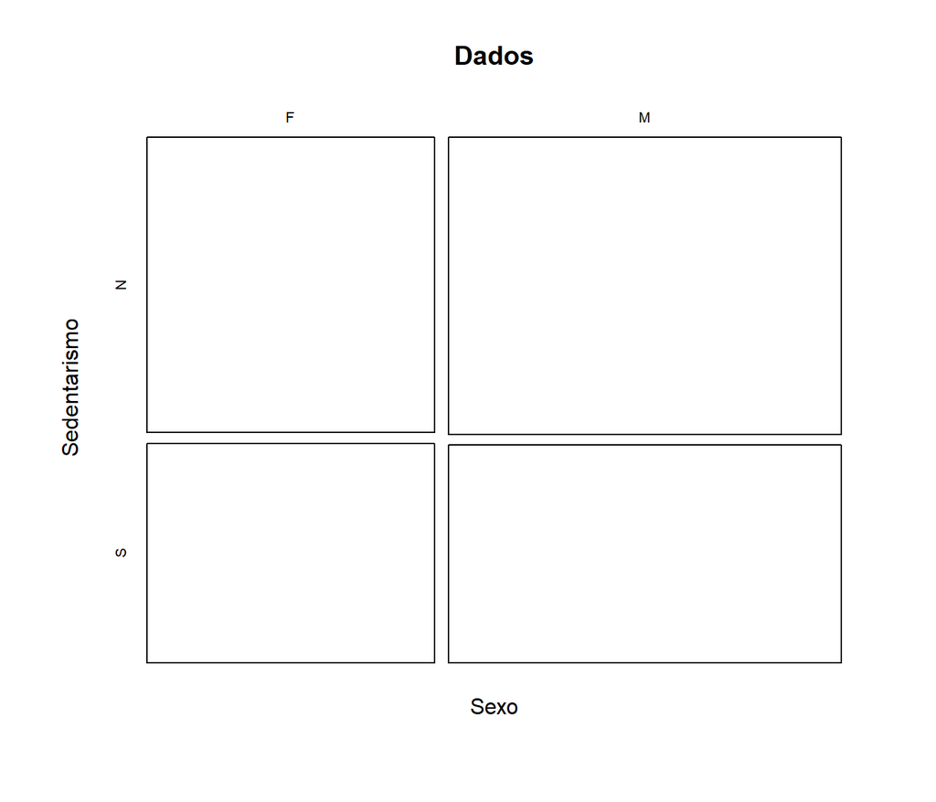

```r
mosaicplot(~Sexo+Sedentarismo, data=Dados, color=FALSE)
```

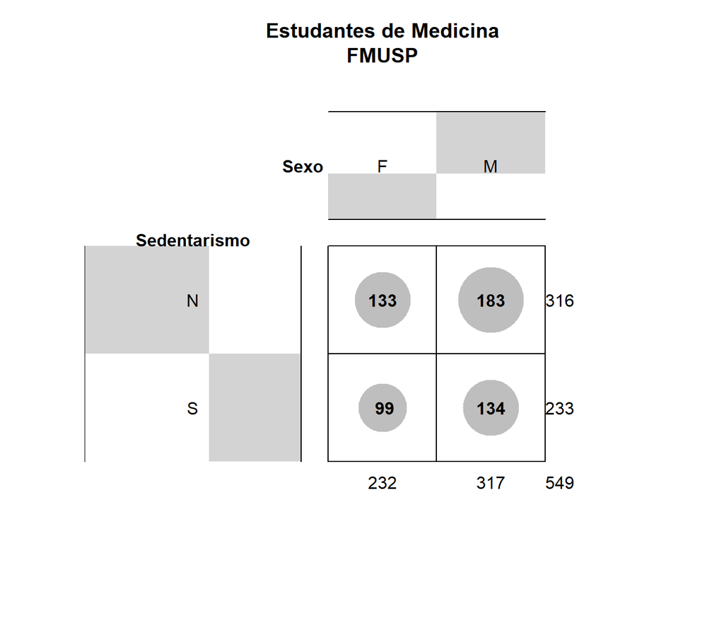

```r
gplots::balloonplot(t(Sedentarismo.Sexo),
                    main ="Estudantes de Medicina\nFMUSP",
                    xlab ="Sexo",
                    ylab="Sedentarismo",
                    label=TRUE,
                    show.margins=TRUE,
                    show.zeros=TRUE,
                    dotcolor="gray")
```

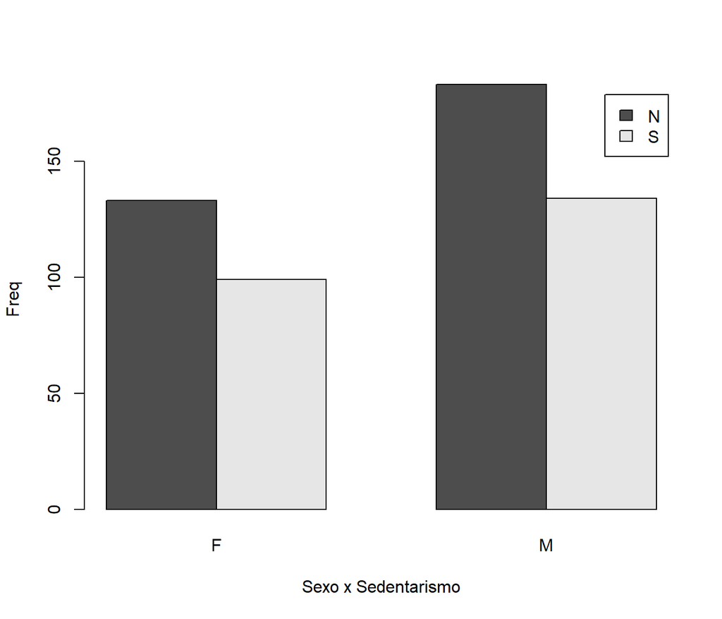

```r
barplot(Sedentarismo.Sexo,
        beside=TRUE,
        legend.text=rownames(Sedentarismo.Sexo),
        ylab="Freq",
        xlab="Sexo x Sedentarismo")
```

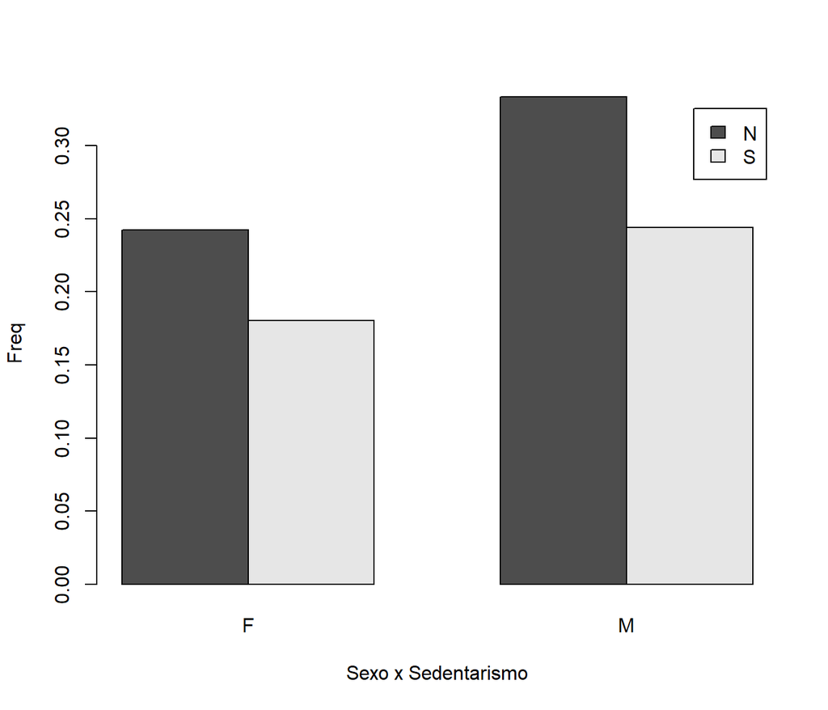

```r
barplot(proportions(Sedentarismo.Sexo),
        beside=TRUE,
        legend.text=rownames(Sedentarismo.Sexo),
        ylab="Freq",
        xlab="Sexo x Sedentarismo")
```

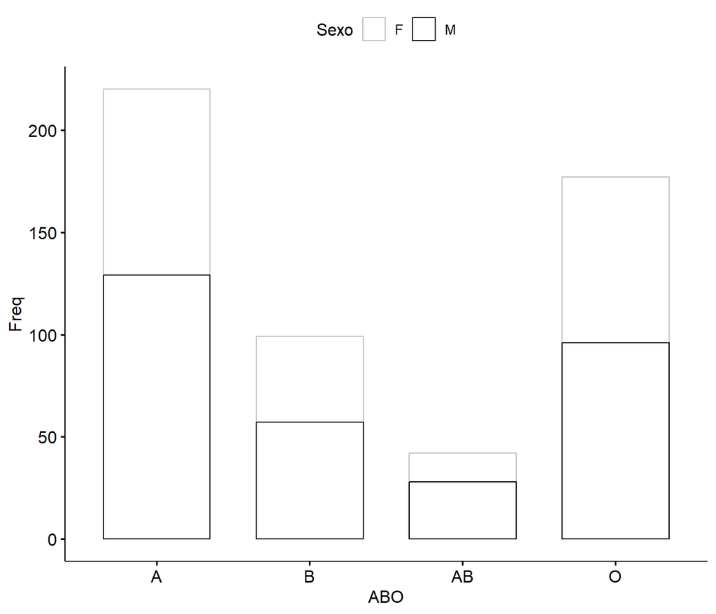

```r
sexo.ABO.freq <- as.data.frame(table(Dados$Sexo, Dados$ABO))
names(sexo.ABO.freq) <- c("Sexo", "ABO", "Freq")
ggpubr::ggbarplot(sexo.ABO.freq,
                  x="ABO",
                  y="Freq",
                  color="Sexo",
                  palette=c("gray", "black"),
                  order=c("A", "B", "AB", "O"),
                  width=.7)
```

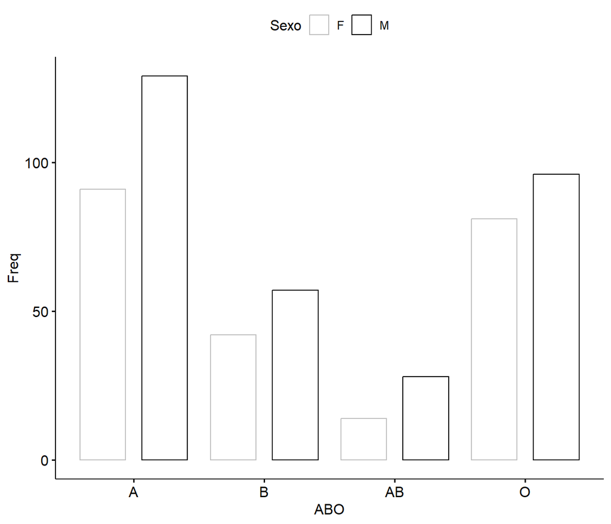

```r
ggpubr::ggbarplot(sexo.ABO.freq,
                  x="ABO",
                  y="Freq",
                  color="Sexo",
                  palette=c("gray", "black"),
                  order=c("A", "B", "AB", "O"),
                  position = ggplot2::position_dodge(),
                  width=.7)
```

## Tabela de contingência 2x4

```r
print(ABO.Sexo <- xtabs(~ABO+Sexo, data=Dados))
```

```
    Sexo
ABO    F   M
  A   91 129
  AB  14  28
  B   42  57
  O   81  96
```

```r
round(proportions(ABO.Sexo),2)
```

```
    Sexo
ABO     F    M
  A  0.17 0.24
  AB 0.03 0.05
  B  0.08 0.11
  O  0.15 0.18
```

```r
round(proportions(ABO.Sexo,1),2)
```

```
    Sexo
ABO     F    M
  A  0.41 0.59
  AB 0.33 0.67
  B  0.42 0.58
  O  0.46 0.54
```

```r
round(proportions(ABO.Sexo,2),2)
```

```
    Sexo
ABO     F    M
  A  0.40 0.42
  AB 0.06 0.09
  B  0.18 0.18
  O  0.36 0.31
```

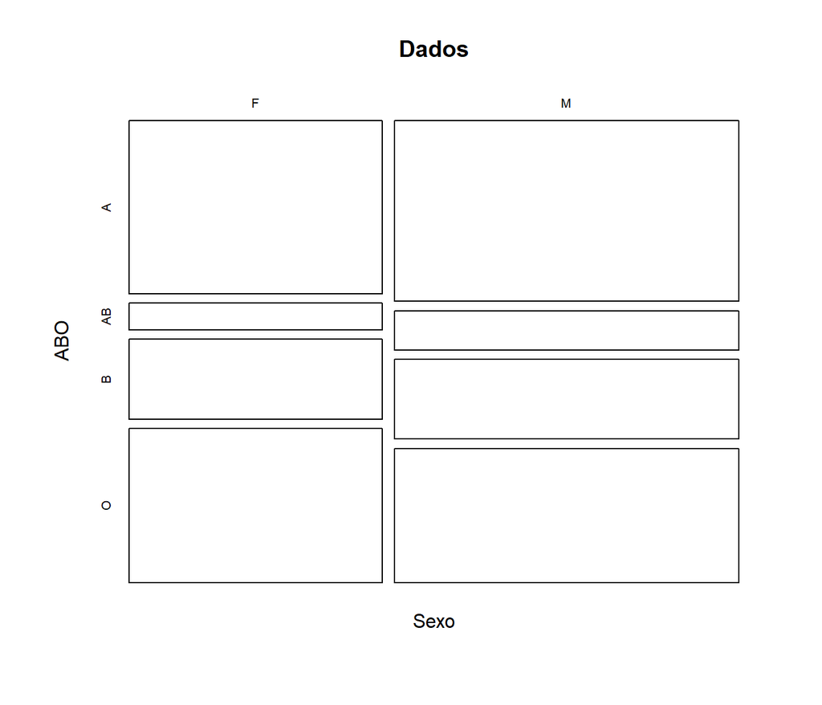

```r
mosaicplot(~Sexo+ABO, data=Dados, color=FALSE)
```

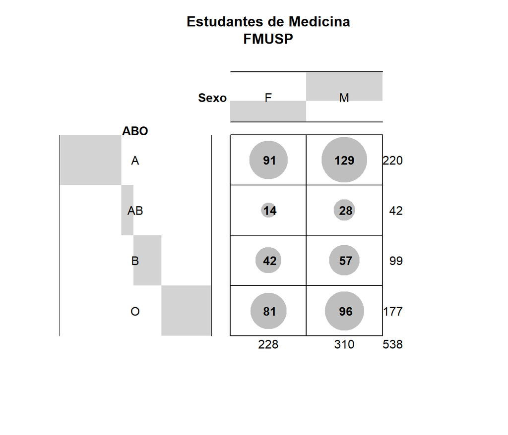

```r
gplots::balloonplot(t(ABO.Sexo),
                    main ="Estudantes de Medicina\nFMUSP",
                    xlab ="Sexo",
                    ylab="ABO",
                    label=TRUE, show.margins=TRUE,
                    show.zeros=TRUE,
                    dotcolor="gray")
```

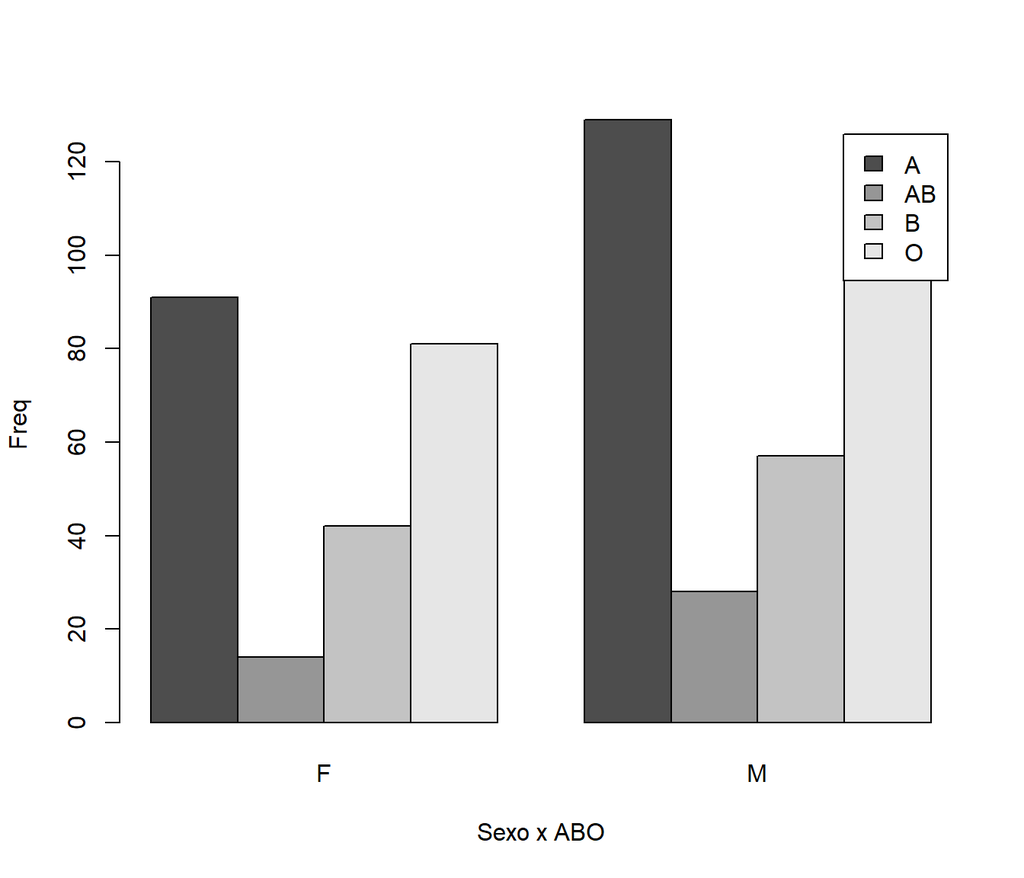

```r
barplot(ABO.Sexo,
        beside=TRUE,
        legend.text=rownames(ABO.Sexo),
        ylab="Freq",
        xlab="Sexo x ABO")
```

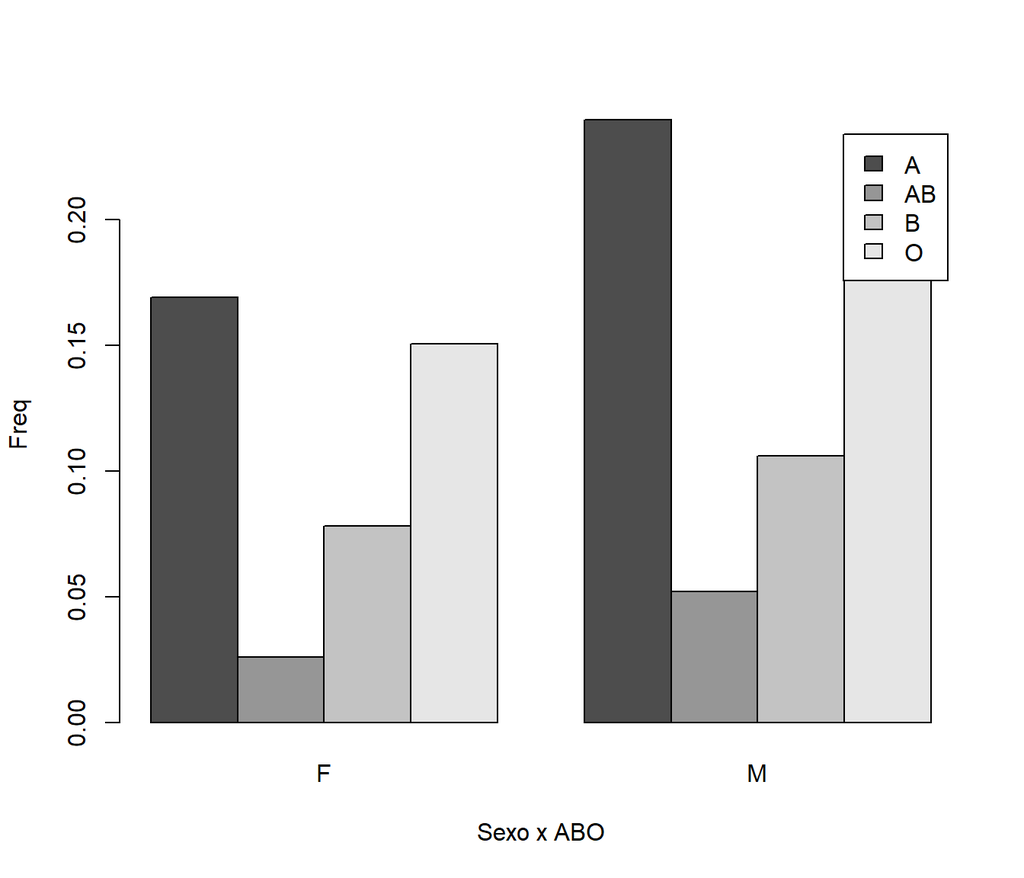

```r
barplot(proportions(ABO.Sexo),
        beside=TRUE,
        legend.text=rownames(ABO.Sexo),
        ylab="Freq",
        xlab="Sexo x ABO")
```

## Tabelas multidimensionais: três ou mais variáveis categóricas

```r
ftable(Sexo + Sedentarismo ~ ABO, data=Dados)
```

```
    Sexo          F     M
    Sedentarismo  N  S  N  S
ABO
A                51 40 83 46
AB                9  5 12 16
B                26 16 27 30
O                45 36 56 40
```

```r
print(xtabs(~Sexo + Sedentarismo + ABO, data=Dados))
```

```
, , ABO = A

    Sedentarismo
Sexo  N  S
   F 51 40
   M 83 46

, , ABO = AB

    Sedentarismo
Sexo  N  S
   F  9  5
   M 12 16

, , ABO = B

    Sedentarismo
Sexo  N  S
   F 26 16
   M 27 30

, , ABO = O

    Sedentarismo
Sexo  N  S
   F 45 36
   M 56 40
```

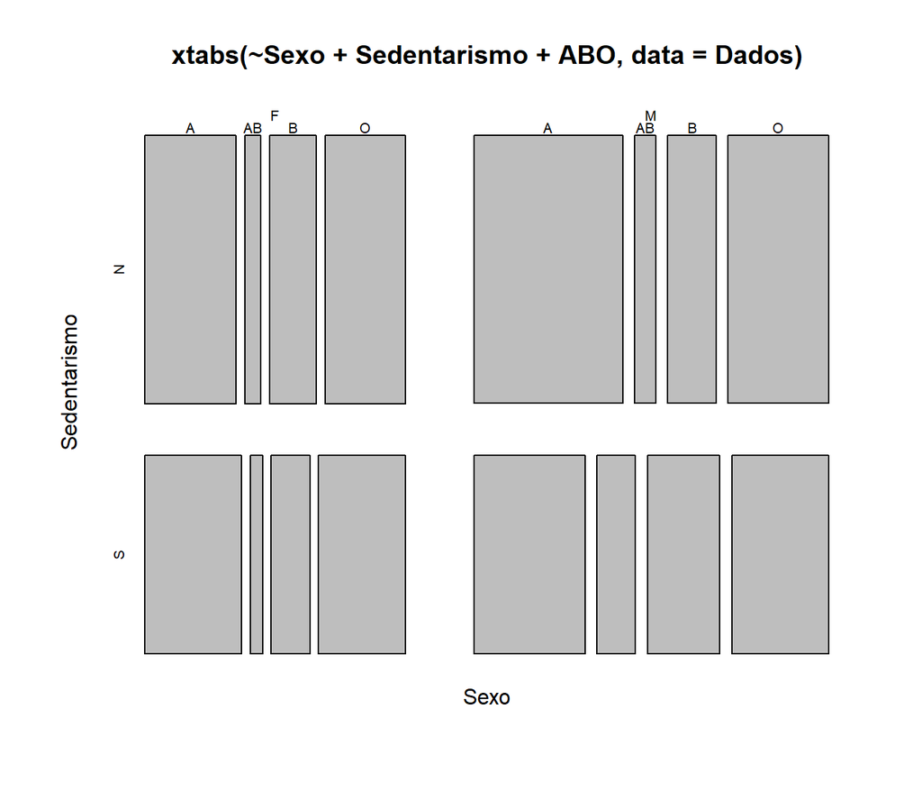

```r
mosaicplot(xtabs(~Sexo + Sedentarismo + ABO, data=Dados))
```

## Boxplot: estrutura

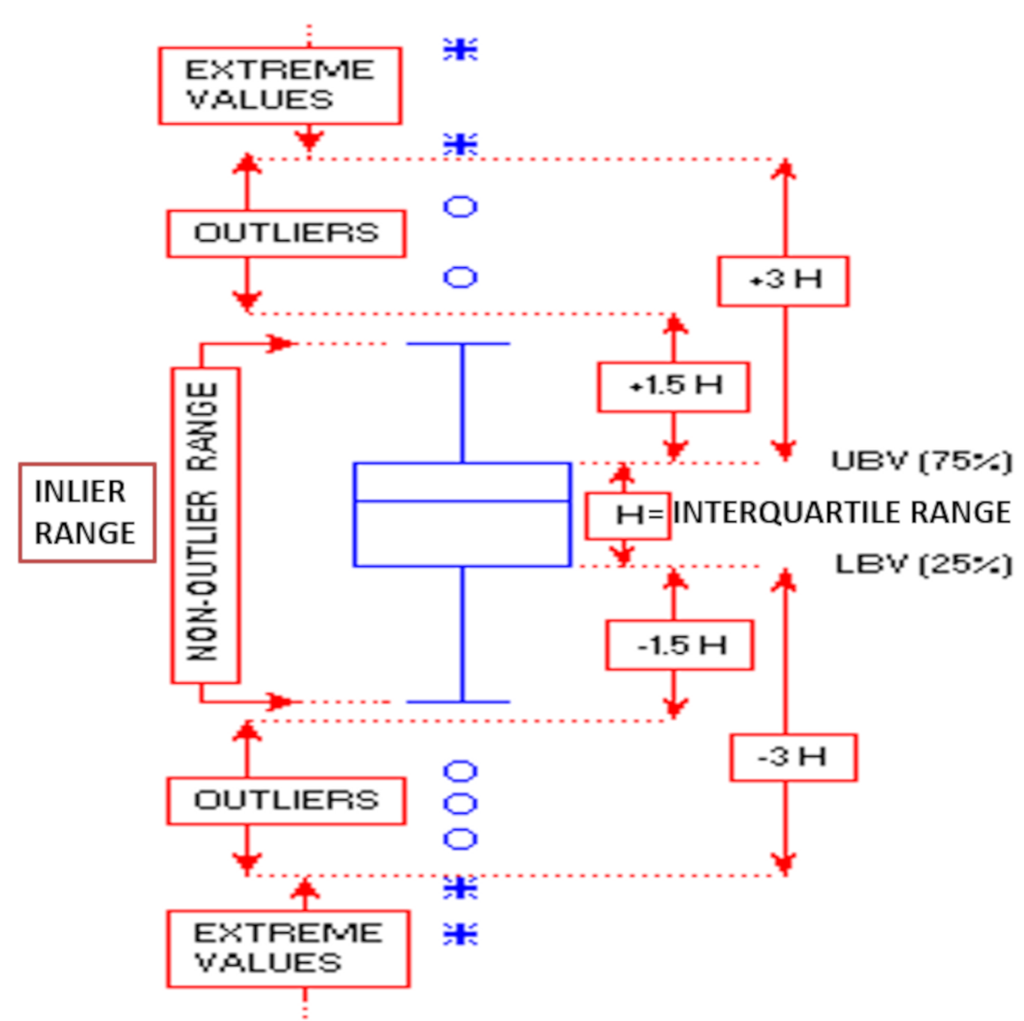

```r
knitr::include_graphics("./image/IQR.png")
```

## Boxplot

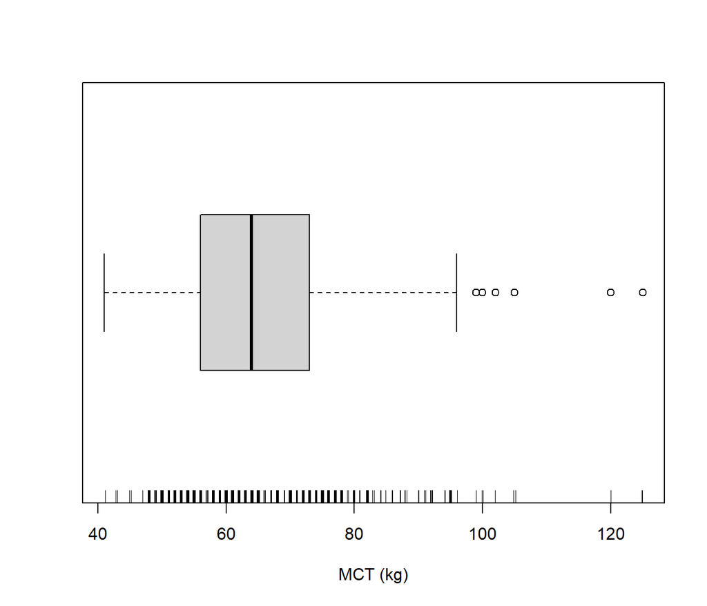

```r
boxplot(Dados$MCT, horizontal=TRUE,
        xlab="MCT (kg)")
rug(jitter(Dados$MCT))
```

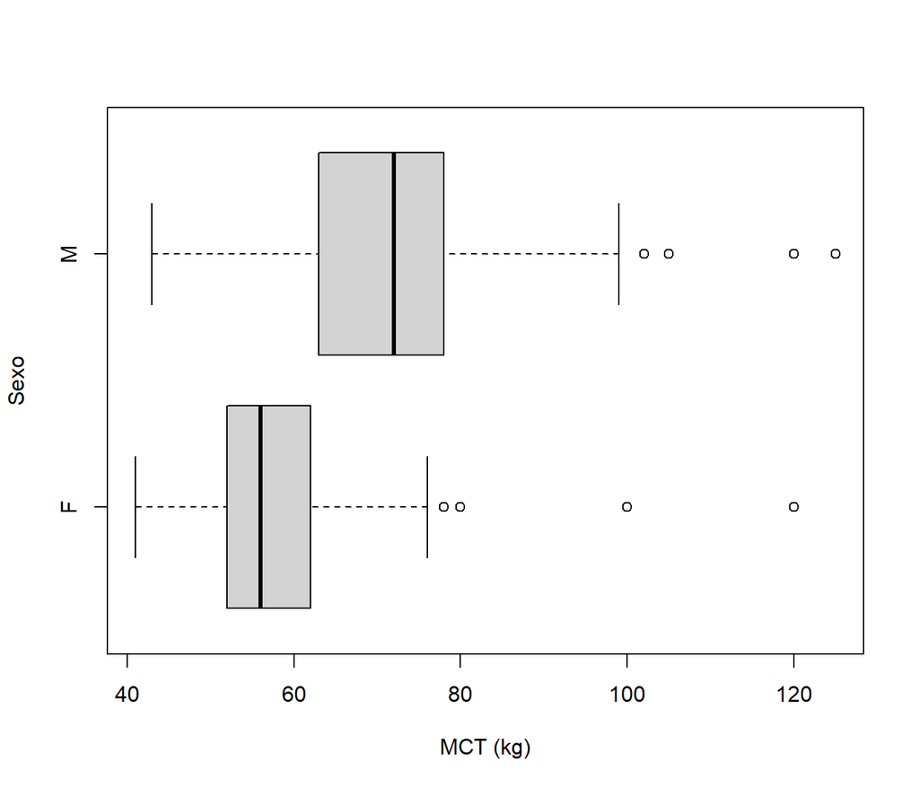

```r
boxplot(MCT~Sexo, data=Dados, horizontal=TRUE,
        xlab="MCT (kg)")
```

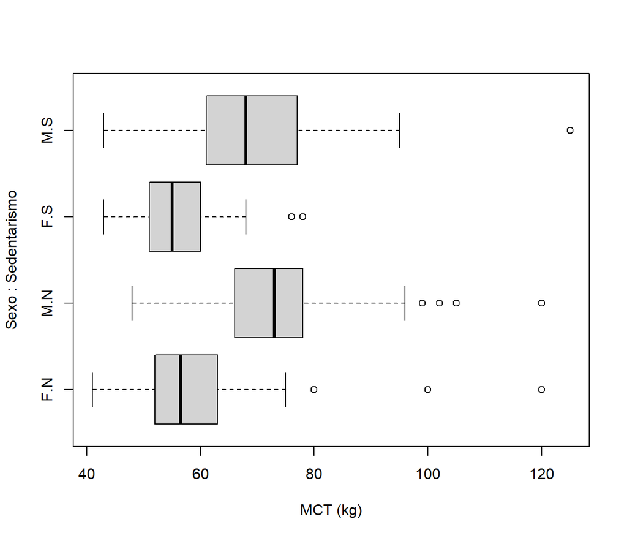

```r
boxplot(MCT~Sexo+Sedentarismo, data=Dados, horizontal=TRUE,
        xlab="MCT (kg)")
```

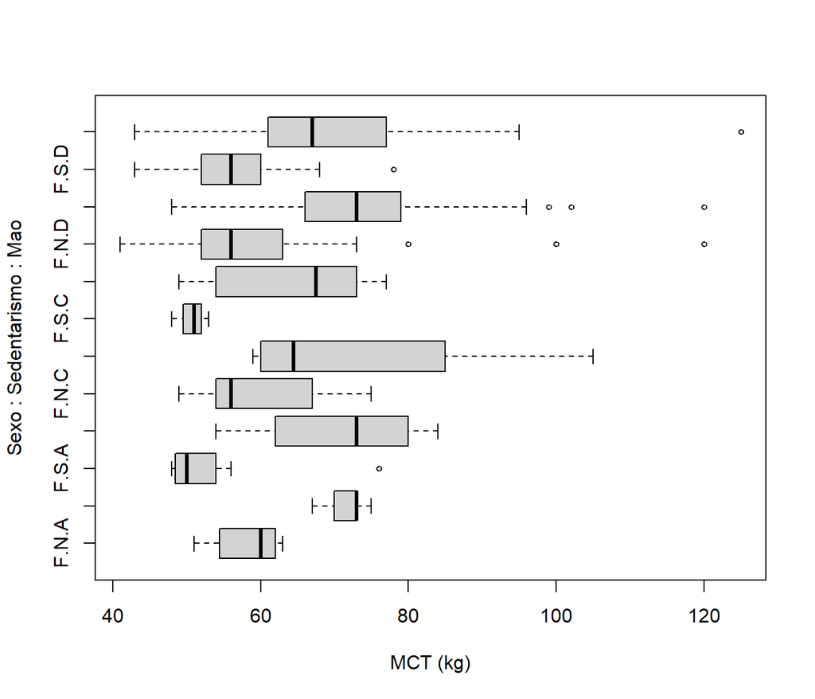

```r
boxplot(MCT~Sexo+Sedentarismo+Mao, data=Dados, horizontal=TRUE,
        xlab="MCT (kg)", cex=0.6)
```

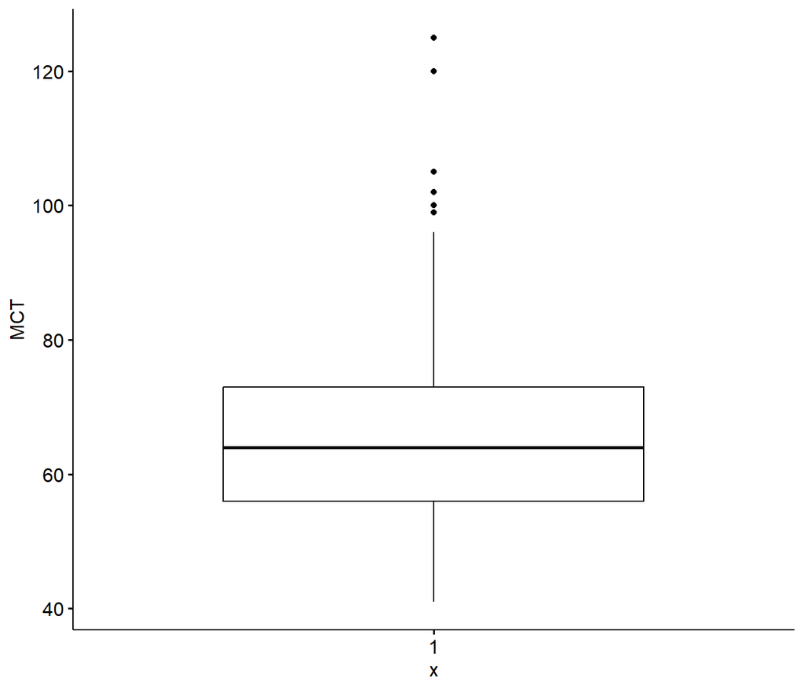

```r
ggpubr::ggboxplot(data=Dados,
                  y="MCT")
```

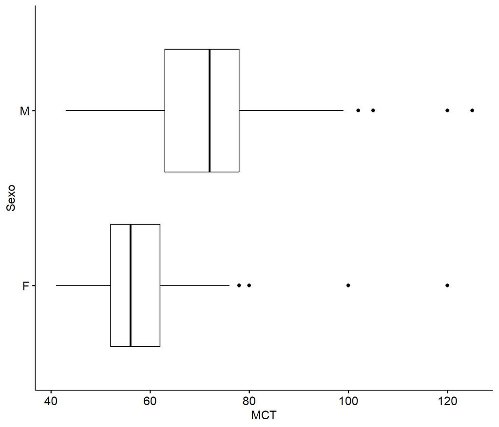

```r
ggpubr::ggboxplot(data=Dados,
                  x="Sexo",
                  y="MCT",
                  add="",
                  orientation="horizontal",
                  width=.7,
                  order=c("F", "M"))
```

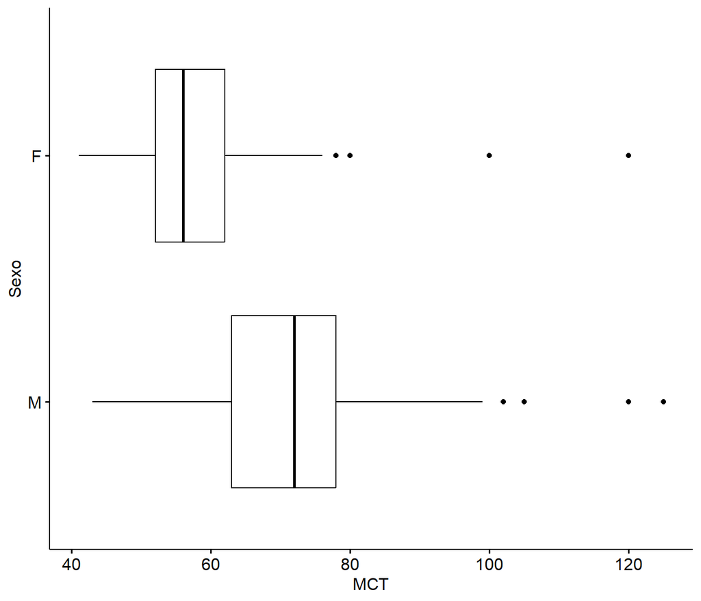

```r
ggpubr::ggboxplot(data=Dados,
                  x="Sexo",
                  y="MCT",
                  add="",
                  orientation="horizontal",
                  width=.7,
                  order=c("M", "F"))
```

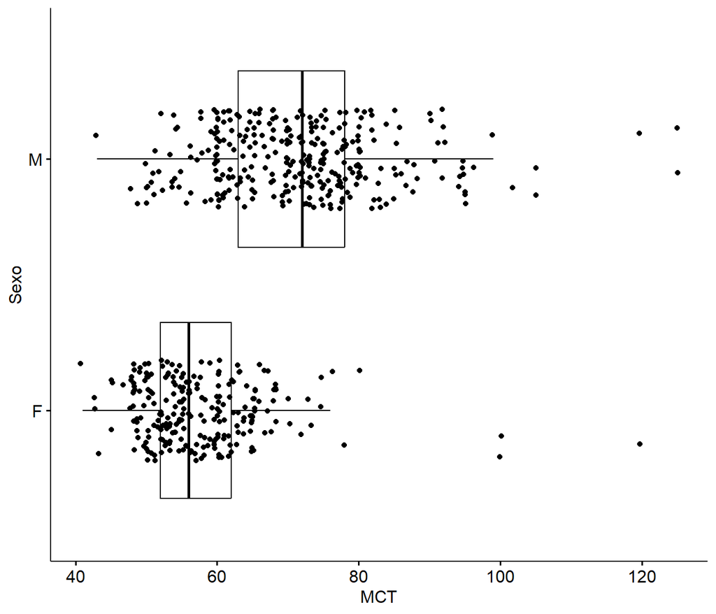

```r
ggpubr::ggboxplot(data=Dados,
                  x="Sexo",
                  y="MCT",
                  add="jitter",
                  orientation="horizontal",
                  width=.7,
                  order=c("F", "M"))
```

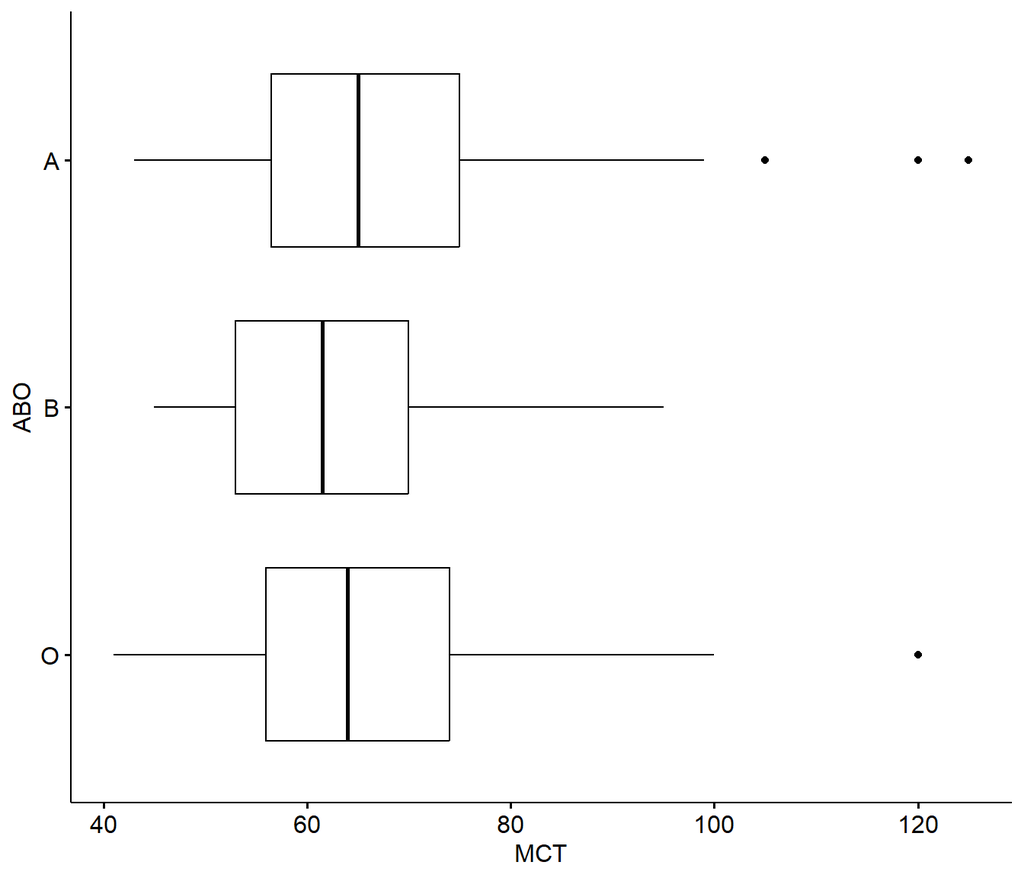

```r
ggpubr::ggboxplot(data=Dados,
                  x="ABO",
                  y="MCT",
                  add="",
                  orientation="horizontal",
                  width=.7,
                  select=c("A", "B", "O"),
                  order=c("O", "B", "A"))
```

## Bagplot: boxplot bidimensional

```r
bgp.F <- DescTools::PlotBag(Dados.F$Estatura,
                            Dados.F$MCT,
                            main=paste("Feminino"),
                            xlab="Estatura (cm)",
                            ylab="Massa Corporal Total (kg)",
                            na.rm=TRUE,
                            show.bagpoints=FALSE,
                            show.looppoints=FALSE,
                            show.whiskers=FALSE,
                            show.baghull=TRUE,
                            col.loophull="white",
                            col.looppoints="black",
                            col.baghull="white",
                            col.bagpoints="black",
                            add=FALSE,
                            cex=1)
```

```
[1] "Warning: NA elements have been removed!!"
```

```r
print(outliers.F <- as.data.frame(bgp.F$pxy.outlier))
```

```
    x   y
1 165 100
2 165 100
3 158  78
```

```r
for (o in 1:nrow(outliers.F))
{
  r.F <- which(Dados.F$Estatura==outliers.F$x[o] &
               Dados.F$MCT==outliers.F$y[o])
  text(outliers.F$x[o],outliers.F$y[o], r.F, pos=1, cex=0.7)
}
```

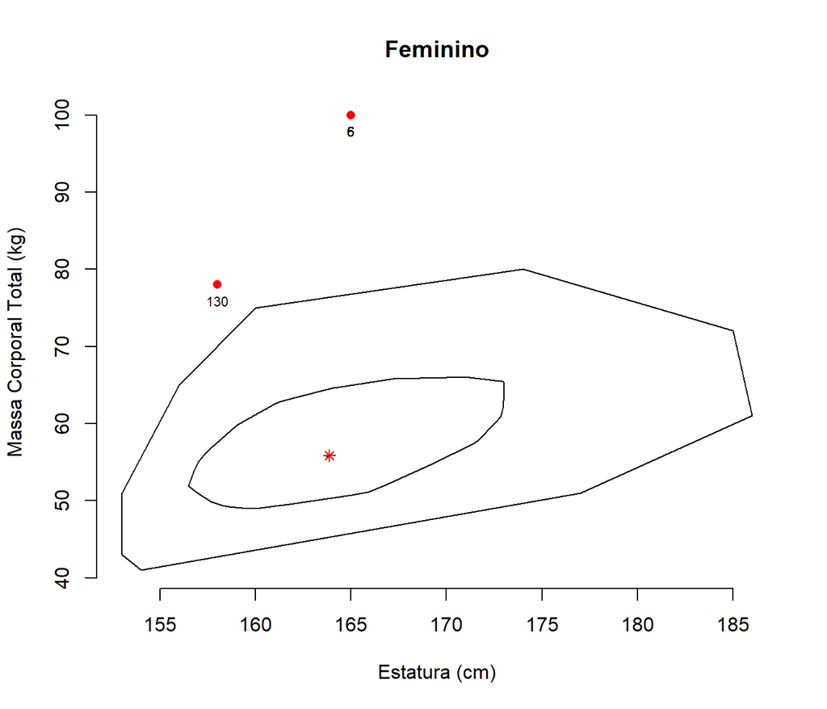

```r
bgp.M <- DescTools::PlotBag(Dados.M$Estatura,
                          Dados.M$MCT,
                          main=paste("Masculino"),
                          xlab="Estatura (cm)",
                          ylab="Massa Corporal Total (kg)",
                          na.rm=TRUE,
                          show.bagpoints=FALSE,
                          show.looppoints=FALSE,
                          show.whiskers=FALSE,
                          show.baghull=TRUE,
                          col.loophull="white",
                          col.looppoints="black",
                          col.baghull="white",
                          col.bagpoints="black",
                          add=FALSE,
                          cex=1)
```

```
[1] "Warning: NA elements have been removed!!"
```

```r
print(outliers.M <- as.data.frame(bgp.M$pxy.outlier))
```

```
    x   y
1 165  94
2 193 120
3 184 125
4 176 125
```

```r
for (o in 1:nrow(outliers.M))
{
  r.M <- which(Dados.M$Estatura==outliers.M$x[o] &
                 Dados.M$MCT==outliers.M$y[o])
  text(outliers.M$x[o], outliers.M$y[o], r.M, pos=1, cex=0.7)
}
```

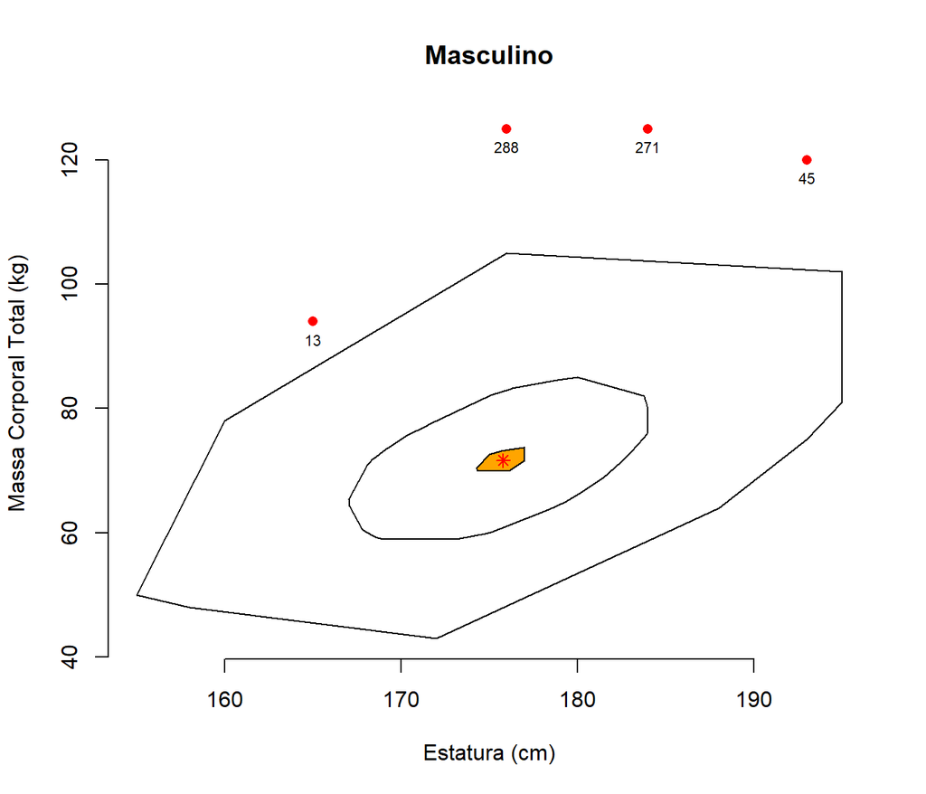